# R Notebook

Q1. From the dataset `heights` in the `dslabs` package, please describe the distribution of male and female heights. If you pick a female at random, what is the probability that she is 61 inches or shorter?

A1.

```r
library(tidyverse)
library(dslabs)
library(dplyr)
library(cowplot)
```

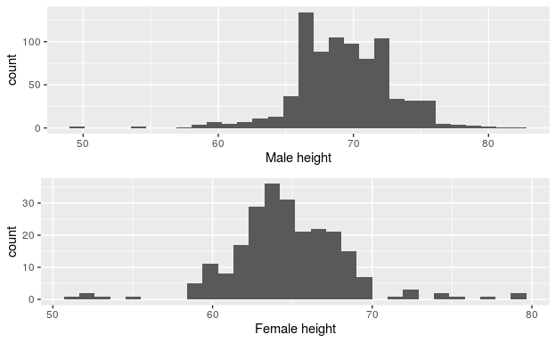

```r
p1 <- heights %>% filter(sex=="Male") %>% ggplot(aes(height)) + geom_histogram() + labs(x="Male height")
p2 <- heights %>% filter(sex=="Female") %>% ggplot(aes(height)) + geom_histogram() + labs(x="Female height")
plot_grid(p1, p2, nrow=2)
```

히스토그램으로 분포를 나타내었다. 두 그래프 모두 대체적으로 정규분포 형태임을 확인할 수 있다.

```r
heights %>% filter(sex=="Male") %>% summarize(mean(height), sd(height))
```

| mean(height) | sd(height) |
| --- | --- |
| 69.31475 | 3.611024 |

남자의 경우 height mean이 69.31475, standard deviation이 3.611024이다.

```r
heights %>% filter(sex=="Female") %>% summarize(mean(height), sd(height))
```

| mean(height) | sd(height) |
| --- | --- |
| 64.93942 | 3.760656 |

여자의 경우 height mean이 64.93942, standard deviation이 3.760656이다.

```r
1 - pnorm(61, 64.9394, 3.760656)
```

```
[1] 0.8525724
```

Q2. For American Roulette, there are 19 reds, 16 blacks and 3 greens. The payout for winning on green is 15 dollars. You create a random variable that is the sum of your winnings after betting on green 1000 times. Start your code by setting the seed to 1. Describe your random variable (e.g. the expected value, the standard error). Then, create a Monte Carlo simulation that generates 1,000 outcomes of a random variable, and then describe your result.

A2. Green에 걸리면 15달러를 받고, 그렇지 않으면 1달러를 잃는다.

```r
set.seed(1)
p <- 3/(19+16+3)
B <- 1000
greeeen <- sample(c(15,-1), B, replace=TRUE, prob = c(p, 1-p))
S <- sum(greeeen)
S
```

```
[1] 472
```

이번 실행에서 472달러를 얻었다!

Expected value of the sum S is

```r
m <- B * (p*15 + (1-p)*-1)
m
```

```
[1] 263.1579
```

기댓값은 263.1579

Standard Error of S is

```r
se<-sqrt(B) * abs(15+1)*sqrt(p*(1-p))
se
```

```
[1] 136.4366
```

standard error는 136.4366이다.

```r
1-pnorm(0, m, se)
```

```
[1] 0.9731216
```

1000번 betting을 했을 때 돈을 얻을 확률은 0.9731216이다.

1000번의 결과가 나오는 monte carlo simulation을 했다.

```r
listoutcome <- replicate(B,{
  X <- sample(c(15,-1), B, replace=TRUE, prob = c(p, 1-p))
  sum(X)
})
mean(listoutcome)
```

```
[1] 256.672
```

```r
sd(listoutcome)
```

```
[1] 137.9666
```

```r
mean(listoutcome>0)
```

```
[1] 0.975
```

1000번 betting을 1000번 반복했을 때 돈을 얻을 확률의 mean을 구하면 0.975이다.

Q3. From the poll example, we will create a Monte Carlo simulation for p = 0.45. You will compare the sampling size (N) for 10, 1000, and the repeat size (B) for 100, 10000. So you should have four combinations (10 N x 100 B, 1000 N x 100 B, 10 N x 10000 B, 1000 N x 10000 B). Please describe your Monte Carlo simulation results, and compare four combinations. A3.

```r
p <- 0.45
N1 <- 10
B1 <- 100
x_hat1 <- replicate(B1, {
  x <- sample(c(0,1), size = N1, replace = TRUE, prob = c(1-p, p))
  mean(x)
})

p <- 0.45
N2 <- 1000
B2 <- 100
x_hat2 <- replicate(B2, {
  x <- sample(c(0,1), size = N2, replace = TRUE, prob = c(1-p, p))
  mean(x)
})

p <- 0.45
N3 <- 10
B3 <- 10000
x_hat3 <- replicate(B3, {
  x <- sample(c(0,1), size = N3, replace = TRUE, prob = c(1-p, p))
  mean(x)
})

p <- 0.45
N4 <- 1000
B4 <- 10000
x_hat4 <- replicate(B4, {
  x <- sample(c(0,1), size = N4, replace = TRUE, prob = c(1-p, p))
  mean(x)
})
```

10 N x 100 B, 1000 N x 100 B, 10 N x 10000 B, 1000 N x 10000 B 각각의 경우를 x_hat1, x_hat2, x_hat3, x_hat4라고 나타내었다.

```r
mean(x_hat1)
```

```
[1] 0.455
```

```r
sd(x_hat1)
```

```
[1] 0.1585127
```

```r
mean(x_hat2)
```

```
[1] 0.45032
```

```r
sd(x_hat2)
```

```
[1] 0.01577421
```

```r
mean(x_hat3)
```

```
[1] 0.44805
```

```r
sd(x_hat3)
```

```
[1] 0.15915
```

```r
mean(x_hat4)
```

```
[1] 0.4501311
```

```r
sd(x_hat4)
```

```
[1] 0.01568893
```

10 N x 100 B, 1000 N x 100 B, 10 N x 10000 B, 1000 N x 10000 B 각각의 경우에 대해 mean, sd를 확인했다. mean은 대체적으로 비슷하지만 sd에서 차이를 보였다. 당연하게도 N이 10일때보다 1000일 때 sd값이 더 작았다.

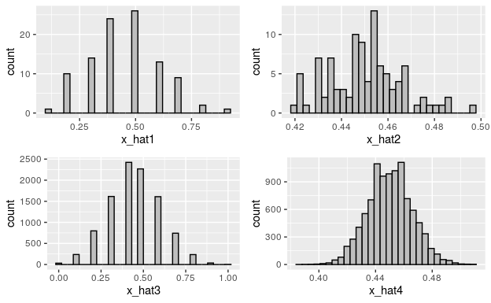

```r
plot1 <- data.frame(x_hat1) %>% ggplot((aes(x_hat1))) + geom_histogram(color="black", fill="gray")
plot2 <- data.frame(x_hat2) %>% ggplot((aes(x_hat2))) + geom_histogram(color="black", fill="gray")
plot3 <- data.frame(x_hat3) %>% ggplot((aes(x_hat3))) + geom_histogram(color="black", fill="gray")
plot4 <- data.frame(x_hat4) %>% ggplot((aes(x_hat4))) + geom_histogram(color="black", fill="gray")

plot_grid(plot1, plot2, plot3, plot4, ncol=2)
```

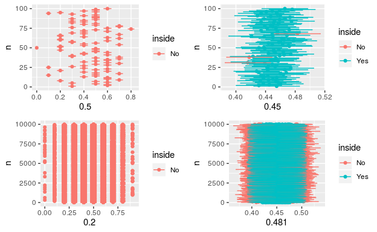

```r
inside1 <- replicate(B1, {
  x <- sample(c(0,1), size = N1, replace = TRUE, prob = c(1-p, p))
  x_hat <- mean(x)
  se_hat <- sqrt(x_hat * (1 - x_hat) / N)
  between(p, x_hat - 1.96 * se_hat, x_hat + 1.96 * se_hat)
  return(c(x_hat, se_hat))
})

inside2 <- replicate(B2, {
  x <- sample(c(0,1), size = N2, replace = TRUE, prob = c(1-p, p))
  x_hat <- mean(x)
  se_hat <- sqrt(x_hat * (1 - x_hat) / N)
  between(p, x_hat - 1.96 * se_hat, x_hat + 1.96 * se_hat)
  return(c(x_hat, se_hat))
})

inside3 <- replicate(B3, {
  x <- sample(c(0,1), size = N3, replace = TRUE, prob = c(1-p, p))
  x_hat <- mean(x)
  se_hat <- sqrt(x_hat * (1 - x_hat) / N)
  between(p, x_hat - 1.96 * se_hat, x_hat + 1.96 * se_hat)
  return(c(x_hat, se_hat))
})

inside4 <- replicate(B4, {
  x <- sample(c(0,1), size = N4, replace = TRUE, prob = c(1-p, p))
  x_hat <- mean(x)
  se_hat <- sqrt(x_hat * (1 - x_hat) / N)
  between(p, x_hat - 1.96 * se_hat, x_hat + 1.96 * se_hat)
  return(c(x_hat, se_hat))
})

d1 <- t(inside1)
dd1 <- as.data.frame(d1) %>% rename(x_hat=V1, se_hat=V2) %>% mutate(lower=x_hat-1.96*se_hat, upper=x_hat+1.96*se_hat, inside=ifelse(lower<=0.45 & upper>=0.45, 'Yes', 'No'), n=seq(1,B1))

d2 <- t(inside2)
dd2 <- as.data.frame(d2) %>% rename(x_hat=V1, se_hat=V2) %>% mutate(lower=x_hat-1.96*se_hat, upper=x_hat+1.96*se_hat, inside=ifelse(lower<=0.45 & upper>=0.45, 'Yes', 'No'), n=seq(1, B2))

d3 <- t(inside3)
dd3 <- as.data.frame(d3) %>% rename(x_hat=V1, se_hat=V2) %>% mutate(lower=x_hat-1.96*se_hat, upper=x_hat+1.96*se_hat, inside=ifelse(lower<=0.45 & upper>=0.45, 'Yes', 'No'), n=seq(1, B3))

d4 <- t(inside4)
dd4 <- as.data.frame(d4) %>% rename(x_hat=V1, se_hat=V2) %>% mutate(lower=x_hat-1.96*se_hat, upper=x_hat+1.96*se_hat, inside=ifelse(lower<=0.45 & upper>=0.45, 'Yes', 'No'), n=seq(1, B4))

p_1 <- dd1 %>% ggplot()+ geom_point(aes(x=x_hat, y=n, color=inside)) +geom_errorbarh(aes(xmax=upper, xmin=lower, y=n, color=inside)) + labs(x=x_hat1)

p_2 <- dd2 %>% ggplot()+ geom_point(aes(x=x_hat, y=n, color=inside)) +geom_errorbarh(aes(xmax=upper, xmin=lower, y=n, color=inside))+ labs(x=x_hat2)

p_3 <-  dd3 %>% ggplot()+ geom_point(aes(x=x_hat, y=n, color=inside)) +geom_errorbarh(aes(xmax=upper, xmin=lower, y=n, color=inside)) + labs(x=x_hat3)

p_4 <-  dd4 %>% ggplot()+ geom_point(aes(x=x_hat, y=n, color=inside)) +geom_errorbarh(aes(xmax=upper, xmin=lower, y=n, color=inside)) + labs(x=x_hat4)

plot_grid(p_1, p_2, p_3, p_4)
```